# Possible States

# Why are USA salaries distributed so unfairly?

(This is a rhetorical question. We can do better.)

```r
# Load necessary packages
library(ggplot2)
library(scales)
```

I pulled USA household salary numbers from this report: https://fas.org/sgp/crs/misc/R43897.pdf

```r
N <- 300e3 # 300 thousand people (million is too computationally intensive)
zero_inflation <- 2000 # add 2k due to zero-inflation
mean_US <- 72641 + zero_inflation
median_US <- 51939 + zero_inflation
```

We set the standard deviation to get us the observed distribution.

```r
sd_US <- 70e3
```

```r
# about 4% of US households make zero dollars
n_4 <- N / 25
no_income <- rep(0, n_4)

n_96 <- n_4 * 24

# have to reparameterize to get the true mean to match up to the set mean: https://msalganik.wordpress.com/2017/01/21/making-sense-of-the-rlnorm-function-in-r/
m <- mean_US
s <- sd_US
location <- log(m^2 / sqrt(s^2 + m^2))
shape <- sqrt(log(1 + (s^2 / m^2)))
salaries <- rlnorm(n_96, location, shape)
dystopia <- data.frame(salaries = c(no_income,salaries))
```

We need to verify that these descriptive statistics roughly correspond to the true US statistics. And yes, the mean and median do roughly match the true values of mean = 72641 and median = 51939:

```r
paste("mean: ",round(mean(dystopia$salaries)))
```

```
## [1] "mean:  71571"
```

```r
paste("median: ",round(median(dystopia$salaries)))
```

```
## [1] "median:  52206"
```

But the bottom quintile is a little too high. The true USA income distribution has a greater number of very poor people, and more people who are absurdly wealthy.

```r
quantile(salaries, probs = c(.2,.8))
```

```
##       20%       80%
##  27890.57 106258.93
```

# The current United States income distribution

Here are our simulated numbers, which approximately match the true values:

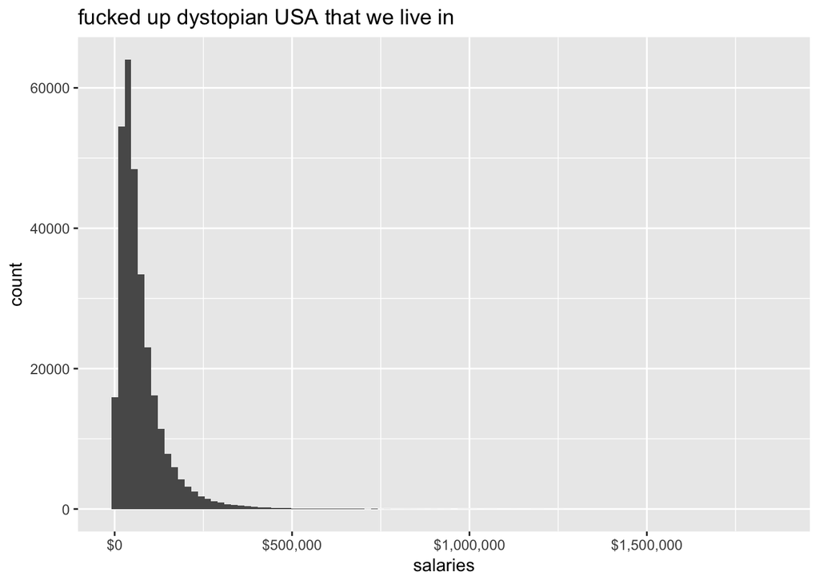

```r
ggplot(dystopia) +
  aes(x = salaries) +
  geom_histogram(bins=100) +
  scale_x_continuous(labels = dollar) +
  ggtitle("fucked up dystopian USA that we live in")
```

# An egalitarian United States income distribution

Now we use the same total dollars to simulate a vaguely egalitarian ecosystem that fulfills the same constraints (e.g. total number of salary dollars).

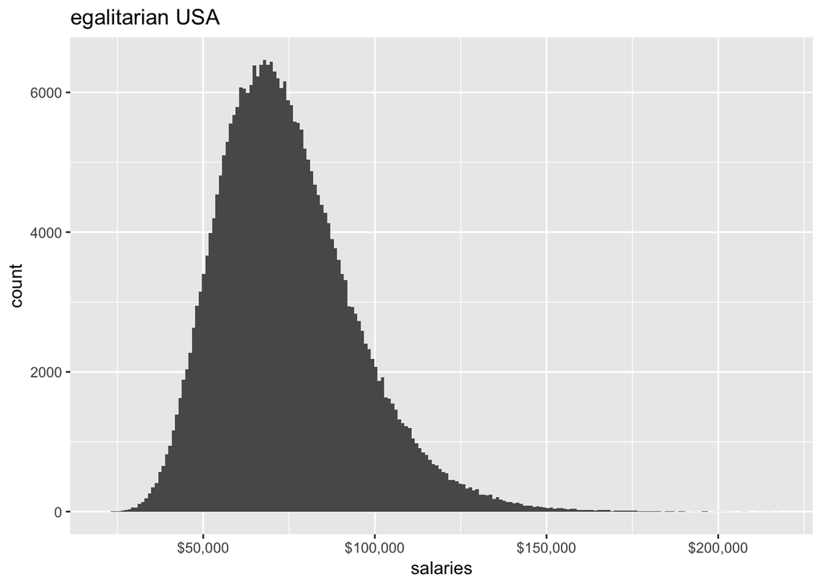

```r
sd_US <- 20e3
m <- mean_US
s <- sd_US
location <- log(m^2 / sqrt(s^2 + m^2))
shape <- sqrt(log(1 + (s^2 / m^2)))
salaries <- (rlnorm(N, location, shape) )
equality <- data.frame(salaries = salaries)
ggplot(equality) + aes(x = salaries) + geom_histogram(bins=200) +
  scale_x_continuous(labels = dollar) +
  ggtitle("egalitarian USA")
```

We can compare the two income distributions back-to-back.

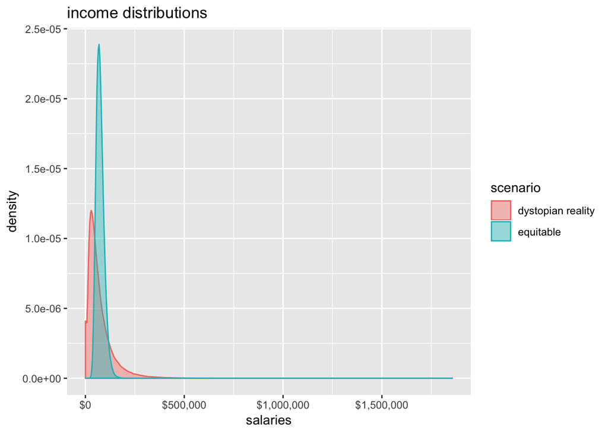

```r
fill <- c(rep("dystopian reality",N),rep("equitable",N))
US <- data.frame(salaries = c(dystopia$salaries,equality$salaries), scenario=fill)

ggplot(US) +
  geom_density(aes(x = salaries, fill =scenario, color=scenario), alpha=.4) +
  scale_x_continuous(labels = dollar) +
  ggtitle("income distributions")
```

```r
summary(equality)
```

```
##     salaries
##  Min.   : 21587
##  1st Qu.: 60337
##  Median : 72144
##  Mean   : 74671
##  3rd Qu.: 86204
##  Max.   :217261
```